# Assignment 2 :

The main objective of the assignment is to find the relationship between the interest rate and the loan variables considering the Fico score.

## Action Plan

1. First do exploratory analysis
2. Make some exploratory plots where you focus on the other variables . You can probably then divide those into 2 groups : those with little influence and those that have some.
3. At that point you can do some more detailed investigation on the latter group.
4. You might then do some formal tests on their correlation, both with the interest rate and with each other (confounders).
5. Then perhaps see if you can build a model where FICO and your selected variables can be used to predict interest rates. Does that tell you anything ?
6. Then write up your methods, findings and results, paying close attention to the rubric (marking script).

PS . One other point - it may be useful to have FICO both as categorical (binned) variable and as a continuous numeric variable. Plenty of other threads on this and how to do it if you wish.

```r
loan <- read.csv("loan.csv")
summary(loan)
```

```
##        X          amount.requested amount.funded.by.investors
##  Min.   :    10   Min.   : 1000    Min.   :    0
##  1st Qu.: 26513   1st Qu.: 6000    1st Qu.: 6000
##  Median : 50633   Median :10000    Median :10000
##  Mean   : 51608   Mean   :12399    Mean   :11995
##  3rd Qu.: 77568   3rd Qu.:17000    3rd Qu.:16000
##  Max.   :104202   Max.   :35000    Max.   :35000
##
##  interest.rate      loan.length               loan.purpose
##  Min.   : 5.42   36 months:1947   debt_consolidation:1305
##  1st Qu.:10.16   60 months: 548   credit_card       : 444
##  Median :13.11                    other             : 199
##  Mean   :13.07                    home_improvement  : 152
##  3rd Qu.:15.80                    major_purchase    : 100
##  Max.   :24.89                    small_business    :  87
##                                   (Other)           : 208
##  debt.to.income.ratio     state       home.ownership monthly.income
##  Min.   : 0.00        CA     : 433   MORTGAGE:1145   Min.   :  588
##  1st Qu.: 9.76        NY     : 251   OTHER   :   5   1st Qu.: 3488
##  Median :15.32        TX     : 174   OWN     : 200   Median : 5000
##  Mean   :15.40        FL     : 169   RENT    :1145   Mean   : 5609
##  3rd Qu.:20.68        IL     : 101                   3rd Qu.: 6750
##  Max.   :34.91        GA     :  98                   Max.   :27083
##                       (Other):1269
##    fico.range   open.credit.lines revolving.credit.balance
##  670-674: 171   Min.   : 2.0      Min.   :     0
##  675-679: 166   1st Qu.: 7.0      1st Qu.:  5588
##  680-684: 157   Median : 9.0      Median : 10948
##  695-699: 153   Mean   :10.1      Mean   : 15201
##  665-669: 145   3rd Qu.:13.0      3rd Qu.: 18850
##  690-694: 140   Max.   :38.0      Max.   :270800
##  (Other):1563
##  inquiries.in.the.last.6.months employment.length
##  Min.   :0.000                  10+ years:651
##  1st Qu.:0.000                  < 1 year :248
##  Median :0.000                  2 years  :244
##  Mean   :0.905                  3 years  :235
##  3rd Qu.:1.000                  5 years  :202
##  Max.   :9.000                  (Other)  :838
##                                 NA's     : 77
```

## Action Plan Step 1: Exploratory Analysis

Purpose : To find out the relationship between the interest rate and other variables and their significance. Action Plan : 2. Make some exploratory plots where you focus on the other variables . You can probably then divide those into 2 groups : those with little influence and those that have some.

**Open Credit Lines vs Interest rate**

Inspect data distribution for open credit lines

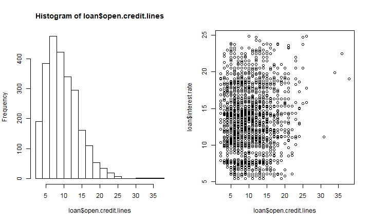

```r
 par(mfrow = c(1, 2))
 hist(loan$open.credit.lines)
 plot(loan$interest.rate ~ loan$open.credit.lines)
```

Data inspection difficult, hence we take the log. Further log is also used to transform the skewed data distribution to normal data distribution.

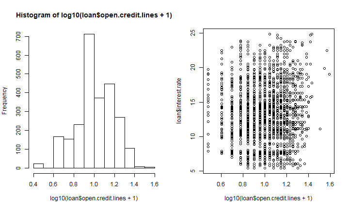

```r
 par(mfrow = c(1, 2))
 hist(log10(loan$open.credit.lines + 1))
 plot(loan$interest.rate ~ log10(loan$open.credit.lines + 1))
```

Conclusion : **NO RELN OBSERVED** No pattern is observed during visual inspection. Hence the varaible open credit lines is concluded to be the variable with very slight relation with the interest rate.

**VARIABLE : Revolving Credit Balance vs Interest rate**

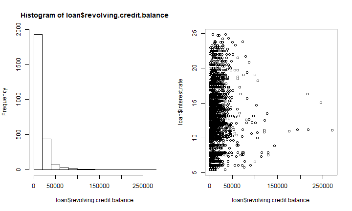

```r
 par(mfrow = c(1, 2))
 hist(loan$revolving.credit.balance)
 plot(loan$interest.rate ~ loan$revolving.credit.balance)
```

Data inspection difficult, hence we take the log. Further log is also used to transform the skewed data distribution to normal data distribution.

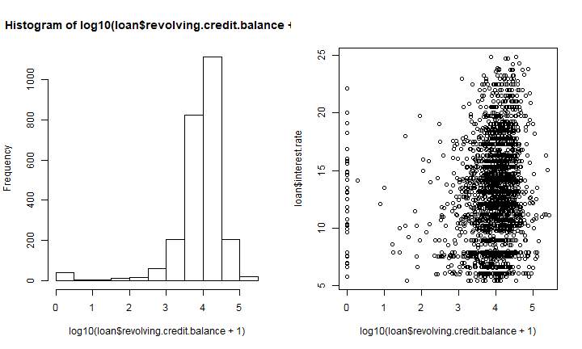

```r
 par(mfrow = c(1, 2))
 hist(log10(loan$revolving.credit.balance + 1))
 plot(loan$interest.rate ~ log10(loan$revolving.credit.balance + 1))
```

Visual inspection too difficult, so we plot linear model line to better see the reln

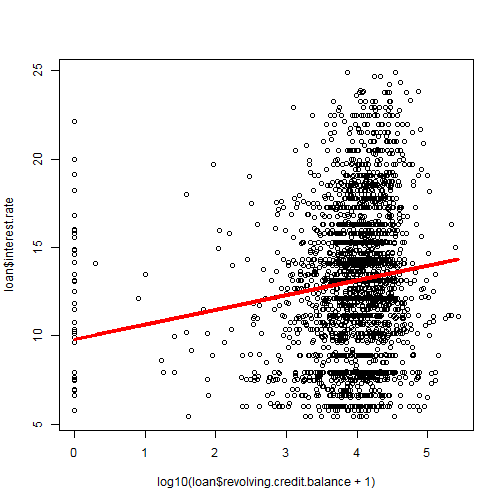

```r
 plot(loan$interest.rate ~ log10(loan$revolving.credit.balance + 1))
 lm <- lm(loan$interest.rate ~ log10(loan$revolving.credit.balance + 1))
 lines(log10(loan$revolving.credit.balance + 1), lm$fitted, col = "red", lwd = 3)
```

Conclusion : **OKAY**, Shows slightly more impact, hence considered for detail analysis for later part.

**VARIABLE : Inquiries in the last 6 month vs Interest rate**

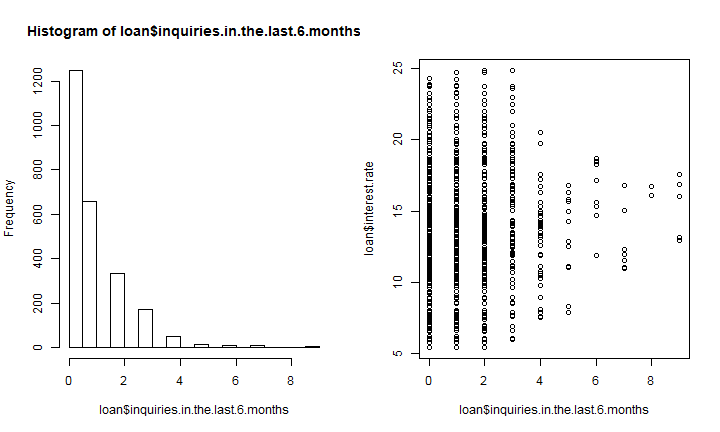

```r
 par(mfrow = c(1, 2))
 hist(loan$inquiries.in.the.last.6.months)
 plot(loan$interest.rate ~ loan$inquiries.in.the.last.6.months)
```

Data inspection difficult, hence take log

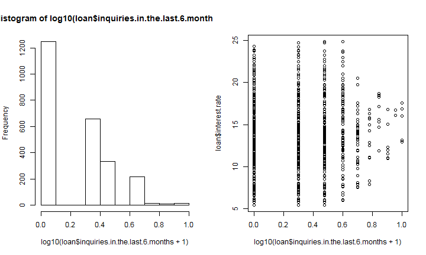

```r
 par(mfrow = c(1, 2))
 hist(log10(loan$inquiries.in.the.last.6.months + 1))
 plot(loan$interest.rate ~ log10(loan$inquiries.in.the.last.6.months + 1))
```

Visual inspection too difficult, so we plot linear model line to better see the reln

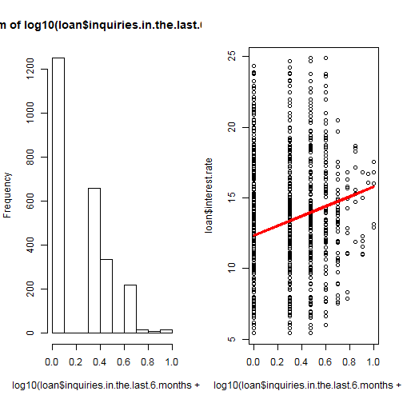

```r
 par(mfrow = c(1, 2))
 hist(log10(loan$inquiries.in.the.last.6.months + 1))
 lm <- lm(loan$interest.rate ~ log10(loan$inquiries.in.the.last.6.months + 1))
 plot(loan$interest.rate ~ log10(loan$inquiries.in.the.last.6.months + 1))
 lines(log10(loan$inquiries.in.the.last.6.months + 1), lm$fitted, col = "red",
     lwd = 3)
```

Conclusion : **OKAY**, Shows slightly more impact, hence considered for detail analysis for later part.

**Attach the loan data to the data frame so that the columsn can then be acessed directly ** dont forget to detach later using detach(loan)

```r
attach(loan)
```

**VARIABLE : Employement length vs Interest rate**

**Reformating of the data** we can convert the emp lenth to ordered factor and then treat or plot the varaible as numeric or we can convert the pordered employement length to numeric.

```r
employment.length <- as.numeric(employment.length)
employment.length[is.na(employment.length)] <- 0
table(employment.length)
```

```
## employment.length
##   0   1   2   3   4   5   6   7   8   9  10  11
##  77 248 177 651 244 235 192 202 163 126 108  72
```

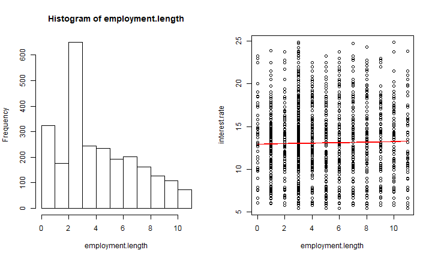

```r
 par(mfrow = c(1, 2))
 hist(employment.length)
 plot(interest.rate ~ employment.length)
 lm_emplen <- lm(interest.rate ~ employment.length)
 lines(employment.length, lm_emplen$fitted, col = "red")
```

Conclusion : **NOT RELEVANT**, Shows almost no impact on the interest rate, when the line was plotted.

** 1. Amount.requested vs inerest.rate

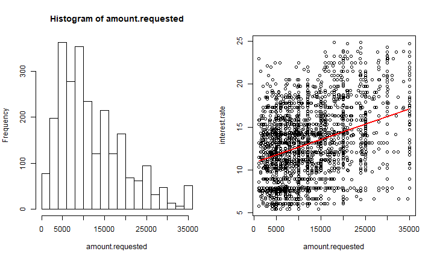

```r
 par(mfrow = c(1, 2))
 hist(amount.requested)
 plot(interest.rate ~ amount.requested)
 lm_amtreq <- lm(interest.rate ~ amount.requested)
 lines(amount.requested, lm_amtreq$fitted, col = "red")
```

```r
 lm_amtreq
```

```
 ##
 ## Call:
 ## lm(formula = interest.rate ~ amount.requested)
 ##
 ## Coefficients:
 ##      (Intercept)  amount.requested
 ##         1.09e+01          1.79e-04
```

```r
 summary(lm_amtreq)
```

```
 ##
 ## Call:
 ## lm(formula = interest.rate ~ amount.requested)
 ##
 ## Residuals:
 ##     Min      1Q  Median      3Q     Max
 ## -10.406  -3.014   0.028   2.713  11.915
 ##
 ## Coefficients:
 ##                  Estimate Std. Error t value Pr(>|t|)
 ## (Intercept)      1.09e+01   1.48e-01    73.2   <2e-16 ***
 ## amount.requested 1.79e-04   1.01e-05    17.6   <2e-16 ***
 ## ---
 ## Signif. codes:  0 '***' 0.001 '**' 0.01 '*' 0.05 '.' 0.1 ' ' 1
 ##
 ## Residual standard error: 3.94 on 2493 degrees of freedom
 ## Multiple R-squared:  0.111, Adjusted R-squared:  0.111
 ## F-statistic:  311 on 1 and 2493 DF,  p-value: <2e-16
```

## ACtion STEP 2: Divide those into 2 groups : those with little influence and those that have some.

```
                              T val        slope       p
```

```r
# Rejected factors 1. open.credit.lines no reln observed during exploratory
# graph 2. revolving.credit.balance go for further exploration 3.  3.13
# 0.000015 0.0018 (**REjected** , cause low T val, with very very low 4.
# #slope val and relatively high p val) 4. employement.length no
```

*** Further analyse few variables ***

*Revolving.credit.balance vs interest rate*

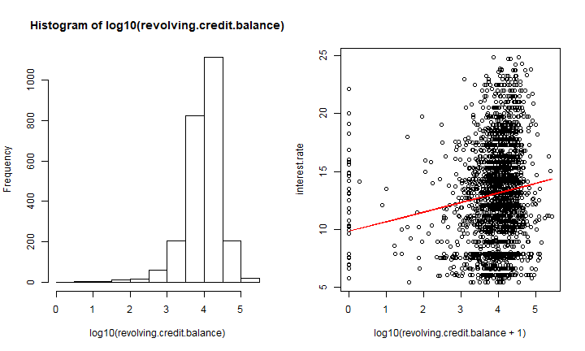

```r
  par(mfrow = c(1, 2))
  hist(log10(revolving.credit.balance))
  plot(interest.rate ~ log10(revolving.credit.balance + 1))
  lm_amtreq <- lm(interest.rate ~ log10(revolving.credit.balance + 1))
  lines(log10(revolving.credit.balance + 1), lm_amtreq$fitted, col = "red")
```

```r
  lm_amtreq
```

```
  ##
  ## Call:
  ## lm(formula = interest.rate ~ log10(revolving.credit.balance +
  ##     1))
  ##
  ## Coefficients:
  ##                         (Intercept)  log10(revolving.credit.balance + 1)
  ##                               9.805                                0.834
```

```r
  summary(lm_amtreq)
```

```
  ##
  ## Call:
  ## lm(formula = interest.rate ~ log10(revolving.credit.balance +
  ##     1))
  ##
  ## Residuals:
  ##    Min     1Q Median     3Q    Max
  ## -8.166 -3.045 -0.081  2.688 12.305
  ##
  ## Coefficients:
  ##                                     Estimate Std. Error t value Pr(>|t|)
  ## (Intercept)                            9.805      0.476   20.58  < 2e-16
  ## log10(revolving.credit.balance + 1)    0.834      0.120    6.97  4.2e-12
  ##
  ## (Intercept)                         ***
  ## log10(revolving.credit.balance + 1) ***
  ## ---
  ## Signif. codes:  0 '***' 0.001 '**' 0.01 '*' 0.05 '.' 0.1 ' ' 1
  ##
  ## Residual standard error: 4.14 on 2493 degrees of freedom
  ## Multiple R-squared:  0.0191,   Adjusted R-squared:  0.0187
  ## F-statistic: 48.5 on 1 and 2493 DF,  p-value: 4.17e-12
```

without log, distribution

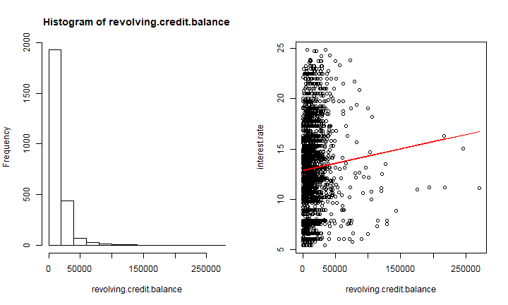

```r
 par(mfrow = c(1, 2))
 hist(revolving.credit.balance)
 plot(interest.rate ~ revolving.credit.balance)
 lm_amtreq <- lm(interest.rate ~ revolving.credit.balance)
 lines(revolving.credit.balance, lm_amtreq$fitted, col = "red")
```

```r
 lm_amtreq
```

```
 ##
 ## Call:
 ## lm(formula = interest.rate ~ revolving.credit.balance)
 ##
 ## Coefficients:
 ##              (Intercept)  revolving.credit.balance
 ##                 1.29e+01                  1.44e-05
```

```r
 summary(lm_amtreq)
```

```
 ##
 ## Call:
 ## lm(formula = interest.rate ~ revolving.credit.balance)
 ##
 ## Residuals:
 ##    Min     1Q Median     3Q    Max
 ## -8.152 -3.017  0.016  2.740 11.929
 ##
 ## Coefficients:
 ##                          Estimate Std. Error t value Pr(>|t|)
 ## (Intercept)              1.29e+01   1.09e-01  118.27   <2e-16 ***
 ## revolving.credit.balance 1.44e-05   4.58e-06    3.14   0.0017 **
 ## ---
 ## Signif. codes:  0 '***' 0.001 '**' 0.01 '*' 0.05 '.' 0.1 ' ' 1
 ##
 ## Residual standard error: 4.17 on 2493 degrees of freedom
 ## Multiple R-squared:  0.00393,   Adjusted R-squared:  0.00353
 ## F-statistic: 9.83 on 1 and 2493 DF,  p-value: 0.00173
```

*Inquiries.in.the.last.6.months vs interest rate*

without log, distribution

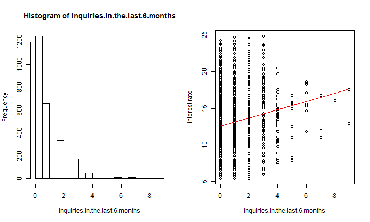

```r
 par(mfrow = c(1, 2))
 hist(inquiries.in.the.last.6.months)
 plot(interest.rate ~ inquiries.in.the.last.6.months)
 lm_amtreq <- lm(interest.rate ~ inquiries.in.the.last.6.months)
 lines(inquiries.in.the.last.6.months, lm_amtreq$fitted, col = "red")
```

```r
 lm_amtreq
```

```
 ##
 ## Call:
 ## lm(formula = interest.rate ~ inquiries.in.the.last.6.months)
 ##
 ## Coefficients:
 ##                    (Intercept)  inquiries.in.the.last.6.months
 ##                         12.564                           0.563
```

```r
 summary(lm_amtreq)
```

```
 ##
 ## Call:
 ## lm(formula = interest.rate ~ inquiries.in.the.last.6.months)
 ##
 ## Residuals:
 ##    Min     1Q Median     3Q    Max
 ## -8.271 -2.942 -0.144  2.673 11.766
 ##
 ## Coefficients:
 ##                                Estimate Std. Error t value Pr(>|t|)
 ## (Intercept)                     12.5639     0.1024   122.7   <2e-16 ***
 ## inquiries.in.the.last.6.months   0.5633     0.0671     8.4   <2e-16 ***
 ## ---
 ## Signif. codes:  0 '***' 0.001 '**' 0.01 '*' 0.05 '.' 0.1 ' ' 1
 ##
 ## Residual standard error: 4.12 on 2493 degrees of freedom
 ## Multiple R-squared:  0.0275,    Adjusted R-squared:  0.0271
 ## F-statistic: 70.5 on 1 and 2493 DF,  p-value: <2e-16
```

## ACTION STEP 4 : do some formal tests on their correlation, both with the interest rate and with each other (confounders).

calculating correlation across all numerical values. We should remove variable if they are too much co related. It implies that the bariables are possible similar

```r
numeric.columns <- names(loan)[unlist(lapply(loan, "class")) %in% c("numeric",
    "integer")]
dn <- as.matrix(loan[, numeric.columns])
cordn <- cor(dn[complete.cases(dn), ])
cordn
```

```
##                                      X amount.requested
## X                              1.00000          0.13197
## amount.requested               0.13197          1.00000
## amount.funded.by.investors     0.17401          0.96964
## interest.rate                  0.24711          0.33311
## debt.to.income.ratio           0.24261          0.08275
## monthly.income                 0.01380          0.45333
## open.credit.lines              0.18084          0.19609
## revolving.credit.balance       0.07877          0.28825
## inquiries.in.the.last.6.months 0.14275         -0.02893
##                                amount.funded.by.investors interest.rate
## X                                                 0.17401       0.24711
## amount.requested                                  0.96964       0.33311
## amount.funded.by.investors                        1.00000       0.33822
## interest.rate                                     0.33822       1.00000
## debt.to.income.ratio                              0.09530       0.17034
## monthly.income                                    0.43077       0.03998
## open.credit.lines                                 0.18597       0.08939
## revolving.credit.balance                          0.25637       0.06268
## inquiries.in.the.last.6.months                   -0.06737       0.16588
##                                debt.to.income.ratio monthly.income
## X                                           0.24261        0.01380
## amount.requested                            0.08275        0.45333
## amount.funded.by.investors                  0.09530        0.43077
## interest.rate                               0.17034        0.03998
## debt.to.income.ratio                        1.00000       -0.16467
## monthly.income                             -0.16467        1.00000
## open.credit.lines                           0.37040        0.22413
## revolving.credit.balance                    0.19328        0.39330
## inquiries.in.the.last.6.months              0.01333        0.02884
##                                open.credit.lines revolving.credit.balance
## X                                        0.18084                  0.07877
## amount.requested                         0.19609                  0.28825
## amount.funded.by.investors               0.18597                  0.25637
## interest.rate                            0.08939                  0.06268
## debt.to.income.ratio                     0.37040                  0.19328
## monthly.income                           0.22413                  0.39330
## open.credit.lines                        1.00000                  0.29186
## revolving.credit.balance                 0.29186                  1.00000
## inquiries.in.the.last.6.months           0.11112                  0.01344
##                                inquiries.in.the.last.6.months
## X                                                     0.14275
## amount.requested                                     -0.02893
## amount.funded.by.investors                           -0.06737
## interest.rate                                         0.16588
## debt.to.income.ratio                                  0.01333
## monthly.income                                        0.02884
## open.credit.lines                                     0.11112
## revolving.credit.balance                              0.01344
## inquiries.in.the.last.6.months                        1.00000
```

Conclusion :Observed strong correlation, almost perfect correlation betn amount requested and amount funded. hence during analysis, we would include one of them with high T value and slope.

1. Then perhaps see if you can build a model where FICO and your selected variables can be used to predict interest rates. Does that tell you anything ?
2. Then write up your methods, findings and results, paying close attention to the rubric (marking script).

PS . One other point - it may be useful to have FICO both as categorical (binned) variable and as a continuous numeric variable. Plenty of other threads on this and how to do it if you wish.